# Fit Ball-Berry Model

Hao-Ran Wu ( haoranwu @ zju.edu.cn )

2022-09-17

In this section we are concerned about how to fit Ball-Berry (BB) model through the function `photo.ballberry.fit()`.

## Code Example(s)

```r
# Fit Ball-Berry Model
# ********************************
#
# Fit Ball-Berry model (Ball et al., 1987) from measured stomatal conductance.
#
# ********************************
# List of variables and units for this example
#
# 'path'        path of a CSV file, which contains five columns (with table titles)
#                * column 1(gs): stomatal conductance (μmol m-2 s-1)
#                * column 2(An): photosynthesis rate (μmol m-2 s-1)
#                * column 3(cs): CO2 concentration of leaf surface (μmol mol-1)
#                * column 4(hs): relative humidity at the leaf surface (from 0-1)
#                * column 5(VPD):vapor pressure deficit (kPa)
#
# ********************************
# Step 1: import package
require(bproce)

# Step 2: choose parameters
path  <- "./data/2-4B Simulated Stomatal Conductance for Ballberry Model.csv"

# Step 3: read data
dat   <- read.csv(path) # read the CSV file
                        #  * column 1 ($gs): stomatal conductance
                        #  * column 2 ($An): photosynthesis rate
                        #  * column 3 ($cs): CO2 concentration of leaf surface
                        #  * column 4 ($hs): relative humidity at the leaf surface
                        #  * column 5 ($VPD): vapor pressure deficit

# Step 4: fit the model
md_bb        <- photo.ballberry.fit(dat)                  # fit Ball-Berry model
fitted_bb_g0 <- md_bb$coef[["g0"]]
fitted_bb_g1 <- md_bb$coef[["g1"]]

cat(
  paste("***** Fit Ball-Berry Model *****\n"),
  paste("g0 = ", fitted_bb_g0, "(mol m−2 s−1)\n"),
  paste("g1 = ", fitted_bb_g1, "(mol m−2 s−1)\n"),
  paste("Multiple R-squared:", md_bb$r.square,"\n"),
  paste("Adjusted R-squared:", md_bb$adj.r.square,"\n")
)

md_leuning <- photo.ballberry.fit(dat, model = "leuning") # fit Leuning model
fitted_leuning_g0  <- md_leuning$coef[["g0"]]
fitted_leuning_g1  <- md_leuning$coef[["g1"]]
fitted_leuning_tau <- md_leuning$coef[["tau"]]

cat(
  paste("***** Fit Leuning Model *****\n"),
  paste("g0 = ", fitted_leuning_g0, "(mol m−2 s−1)\n"),
  paste("g1 = ", fitted_leuning_g1, "(mol m−2 s−1)\n"),
  paste("tau = ", fitted_leuning_tau, "\n"),
  paste("Multiple R-squared:", md_leuning$r.square, "\n"),
  paste("Adjusted R-squared:", md_leuning$adj.r.square, "\n")
)

md_vpd    <- photo.ballberry.fit(dat, model = "vpd")     # fit VPD model
fitted_vpd_g0  <- md_leuning$coef[["g0"]]
fitted_vpd_g1  <- md_leuning$coef[["g1"]]

cat(
  paste("***** Fit VPD Model *****\n"),
  paste("g0 = ", fitted_vpd_g0, "(mol m−2 s−1)\n"),
  paste("g1 = ", fitted_vpd_g1, "(mol m−2 s−1)\n"),
  paste("Multiple R-squared:", md_vpd$r.square, "\n"),
  paste("Adjusted R-squared:", md_vpd$adj.r.square, "\n")
)

# Step 5: model prediction
predicted_gs_bb <- photo.ballberry(dat, g0 = fitted_bb_g0, g1 = fitted_bb_g1)
                    # predict stomatal conductance using Ball-Berry model
predicted_gs_leuning <- photo.ballberry(dat, model = "leuning",
                                        g0 = fitted_leuning_g0,
                                        g1 = fitted_leuning_g1,
                                        tau = fitted_leuning_tau)
                    # predict stomatal conductance using Leuning model
predicted_gs_vpd <- photo.ballberry(dat, model = "vpd",
                                    g0 = fitted_vpd_g0,
                                    g1 = fitted_vpd_g1)

plot(
  dat$cs, dat$gs,
  xlab = expression(CO[2]*" concentration of leaf surface"),
  ylab = "Stomatal Conductance",
  main = "Fit Ball-Berry Model"
)                   # stomatal conductance versus CO2 concentration
lines(dat$cs, predicted_gs_bb, col=2)       # fitted Ball-Berry model
lines(dat$cs, predicted_gs_leuning, col=3)  # fitted Leuning model
lines(dat$cs, predicted_gs_vpd, col=4)      # fitted VPD model
legend("right", pch=c(15, 15, 15), col=c(2, 3, 4), bty="n",
       legend=c("Ball-berry", "Leuning", "VPD"))    # add legends
```

## Explanation

**Step1:** Load the package `bproce` through the `require()` function.

```r
require(bproce)
```

**Step2:** Choose model parameters.

- `path`: the path of a CSV file which the data are to be read from. Each row of the file appears as one line, and columns are separated by commas (,). The first row appears as the table title. The sample file “2-4B Simulated Stomatal Conductance for Ballberry Model” contains fivecolumns:
  - Column 1: Stomatal conductance (µmol m<sup>−2</sup> s<sup>-1</sup>).
  - Column 2: Photosynthesis rate (µmol m<sup>−2</sup> s<sup>-1</sup>).
  - Column 3: CO<sub>2</sub> concentration of leaf surface (µmol mol<sup>-1</sup>).
  - Column 4: Relative humidity at the leaf surface. Valid from 0–1.
  - Column 5: Vapor pressure deficit (kPa). It could be measured at field or be calculated from air temperature and relative humidity (See Section 1-2A, 1-2B).

```r
path  <- "./data/2-4B Simulated Stomatal Conductance for Ballberry Model.csv"
```

**Step3:** Read data. Read the CSV file in table format and creates a data frame through the function `read.csv()`.

```r
dat   <- read.csv(path) # read the CSV file
                        #  * column 1 ($gs): stomatal conductance
                        #  * column 2 ($An): photosynthesis rate
                        #  * column 3 ($cs): CO2 concentration of leaf surface
                        #  * column 4 ($hs): relative humidity at the leaf surface
                        #  * column 5 ($VPD): vapor pressure deficit

head(dat)               # print first parts of the data
```

```
     gs An  cs  hs  VPD
1 0.861 15 100 0.6 2.33
2 0.866 15 105 0.6 2.33
3 0.852 15 110 0.6 2.33
4 0.836 15 115 0.6 2.33
5 0.821 15 120 0.6 2.33
6 0.819 15 125 0.6 2.33
```

**Step4:** Fit the model. As discussed in Section 2-4A, the Ball-Berry model is expressed as:

$$g_s=g_0+g_1·A_n·\frac{h_s}{c_s},\quad (1)$$

where $g_s$ is the stomatal conductance (µmol m<sup>−2</sup> s<sup>−1</sup>), $A_n$ is the photosynthesis rate (µmol m<sup>−2</sup> s<sup>−1</sup>), $h_s$ (valid from 0–1) is the fractional relative humidity at the leaf surface, $c_s$ (µmol mol<sup>-1</sup>) is the CO<sub>2</sub> concentration of the leaf surface, $g_0$ and $g_1$ are empirically estimated intercept and slope, respectively.

```r
md_bb        <- photo.ballberry.fit(dat)                  # fit Ball-Berry model
fitted_bb_g0 <- md_bb$coef[["g0"]]
fitted_bb_g1 <- md_bb$coef[["g1"]]

cat(
  paste("***** Fit Ball-Berry Model *****\n"),
  paste("g0 = ", fitted_bb_g0, "(mol m−2 s−1)\n"),
  paste("g1 = ", fitted_bb_g1, "(mol m−2 s−1)\n"),
  paste("Multiple R-squared:", md_bb$r.square,"\n"),
  paste("Adjusted R-squared:", md_bb$adj.r.square,"\n")
)
```

```
***** Fit Ball-Berry Model *****
 g0 =  0.599231476433784 (mol m−2 s−1)
 g1 =  3.00394080303967 (mol m−2 s−1)
 Multiple R-squared: 0.954633675484953
 Adjusted R-squared: 0.954380232331237
```

A modified Ball-Berry model proposed by Leuning(1990) is expressed as:

$$g_s=g_0+\frac{g_1·A_n}{c_s-\Gamma},\quad (2)$$

where $Γ$ (µmol mol<sup>-1</sup>) is a parameter.

```r
md_leuning <- photo.ballberry.fit(dat, model = "leuning") # fit Leuning model
fitted_leuning_g0  <- md_leuning$coef[["g0"]]
fitted_leuning_g1  <- md_leuning$coef[["g1"]]
fitted_leuning_tau <- md_leuning$coef[["tau"]]

cat(
  paste("***** Fit Leuning Model *****\n"),
  paste("g0 = ", fitted_leuning_g0, "(mol m−2 s−1)\n"),
  paste("g1 = ", fitted_leuning_g1, "(mol m−2 s−1)\n"),
  paste("tau = ", fitted_leuning_tau, "\n"),
  paste("Multiple R-squared:", md_leuning$r.square, "\n"),
  paste("Adjusted R-squared:", md_leuning$adj.r.square, "\n")
)
```

```
***** Fit Leuning Model *****
 g0 =  0.56 (mol m−2 s−1)
 g1 =  7.07644471902271 (mol m−2 s−1)
 tau =  -136.836122394193
 Multiple R-squared: 0.954363247073212
 Adjusted R-squared: 0.953853339219282
```

Another model, which uses vapor pressure deficit (VPD) as one of its variable, is expressed as (Lloyd, 1991; Leuning et al., 1995; Medlyn et al., 2011):

$$g_s=g_0+1.6·(1+\frac{g_1}{\sqrt D_s})·\frac{A_n}{c_s},\quad(4)$$

where $D_s$ (kPa) is the actual VPD.

```r
md_vpd    <- photo.ballberry.fit(dat, model = "vpd")     # fit VPD model
fitted_vpd_g0  <- md_leuning$coef[["g0"]]
fitted_vpd_g1  <- md_leuning$coef[["g1"]]

cat(
  paste("***** Fit VPD Model *****\n"),
  paste("g0 = ", fitted_vpd_g0, "(mol m−2 s−1)\n"),
  paste("g1 = ", fitted_vpd_g1, "(mol m−2 s−1)\n"),
  paste("Multiple R-squared:", md_vpd$r.square, "\n"),
  paste("Adjusted R-squared:", md_vpd$adj.r.square, "\n")
)
```

```
***** Fit VPD Model *****
 g0 =  0.56 (mol m−2 s−1)
 g1 =  7.07644471902271 (mol m−2 s−1)
 Multiple R-squared: 0.209654228918241
 Adjusted R-squared: 0.205238889414991
```

**Step 5:** Model prediction. Predict $g_s$ using the fitted models:

```r
predicted_gs_bb <- photo.ballberry(dat, g0 = fitted_bb_g0, g1 = fitted_bb_g1)
                    # predict stomatal conductance using Ball-Berry model
predicted_gs_leuning <- photo.ballberry(dat, model = "leuning",
                                        g0 = fitted_leuning_g0,
                                        g1 = fitted_leuning_g1,
                                        tau = fitted_leuning_tau)
                    # predict stomatal conductance using Leuning model
predicted_gs_vpd <- photo.ballberry(dat, model = "vpd",
                                    g0 = fitted_vpd_g0,
                                    g1 = fitted_vpd_g1)

print(head(data.frame(               # present the output
  dat$cs,                            # column 1: CO2 concentration of leaf surface
  gs_bb = predicted_gs_bb,           # column 2: results given by Ball-Berry model
  gs_leuning = predicted_gs_leuning, # column 3: results given by Leuning model
  gs_vpd = predicted_gs_vpd          # column 4: results given by VPD model
)), digits = 3)
```

```
  dat.cs gs_bb gs_leuning gs_vpd
1    100 0.870      0.829   1.91
2    105 0.857      0.823   1.85
3    110 0.845      0.818   1.79
4    115 0.834      0.813   1.74
5    120 0.825      0.808   1.69
6    125 0.816      0.803   1.64
```

Create a plot of $g_s$ against $c_s$ to compare observed and predicted values:

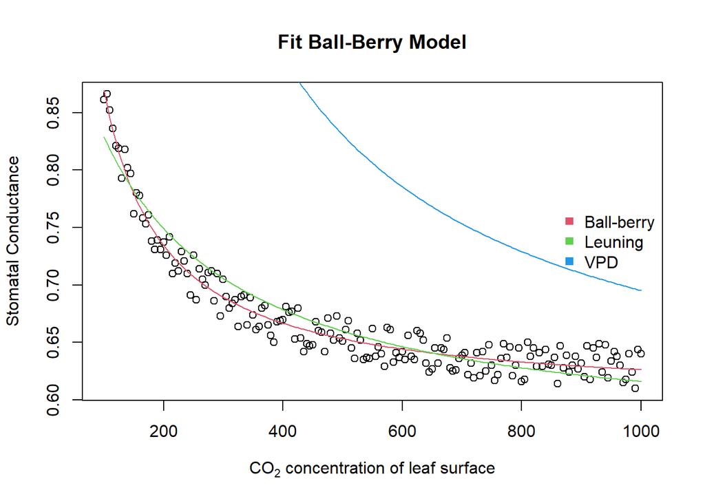

```r
plot(
  dat$cs, dat$gs,
  xlab = expression(CO[2]*" concentration of leaf surface"),
  ylab = "Stomatal Conductance",
  main = "Fit Ball-Berry Model"
)                   # stomatal conductance versus CO2 concentration
lines(dat$cs, predicted_gs_bb, col=2)       # fitted Ball-Berry model
lines(dat$cs, predicted_gs_leuning, col=3)  # fitted Leuning model
lines(dat$cs, predicted_gs_vpd, col=4)      # fitted VPD model
legend("right", pch=c(15, 15, 15), col=c(2, 3, 4), bty="n",
       legend=c("Ball-berry", "Leuning", "VPD"))    # add legends
```

The dots appear on the plot represent the observed values, whilst the solid curve represents the fitted curve. It can be seen that both BB and Leuning model gives a good fit, however VPD model cannot be fitted to the observed data.

## References

Ball, J. T., Woodrow, I. E., and Berry, J. A. (1987). A model predicting stomatal conductance and its contribution to the control of photosynthesis under different environmental conditions. In Progress in Photosynthesis Research (pp. 221–224). Springer, Dordrecht. http://doi.org/10.1007/978-94-017-0519-6-48.

Leuning, R. (1990). Modelling stomatal behaviour and photosynthesis of Eucalyptus grandis. Functional Plant Biology, 17(2), 159–175.

Leuning, R. (1995). A critical appraisal of a combined stomatal‐photosynthesis model for C<sub>3</sub> plants. Plant, Cell & Environment, 18(4), 339–355.

Lloyd, J. (1991). Modelling stomatal responses to environment in Macadamia integrifolia. Functional Plant Biology, 18(6), 649–660.

Medlyn, B. E., Duursma, R. A., Eamus, D., Ellsworth, D. S., Prentice, I. C., Barton, C. V., Crous, K. Y., De Angelis, P., Freeman, M., and Wingate, L. (2011). Reconciling the optimal and empirical approaches to modelling stomatal conductance. Global Change Biology, 17(6), 2134–2144.